# Mixed Models Workshop - Worksheet 2

Andrew Stewart

```r
library(tidyverse)
library(lme4)
library(lmerTest)
library(emmeans)
library(arm)
```

# Modelling a binomial response variable

Now we’re going to have a go at examining some binomial data. 32 partcipants saw images of 32 faces and had to classify images as whether each was happy or sad. We want to determine whether people were more accurate (indicatad by a 1 in the Acc column) for Sad or Happy faces.

```r
my_data <- read_csv("worksheet_data/accuracy_data.csv")
```

```r
my_data$Subject <- as.factor(my_data$Subject)
my_data$Face <- as.factor(my_data$Face)
my_data$FaceExpression <- as.factor(my_data$FaceExpression)
```

Let’s generate some summary stats first.

```r
my_data %>%
  group_by(FaceExpression) %>%
  summarise(mean = mean(Acc), sd = sd (Acc))
```

```
## # A tibble: 2 x 3
##   FaceExpression  mean    sd
##   <fct>          <dbl> <dbl>
## 1 Happy          0.926 0.262
## 2 Sad            0.986 0.120
```

We can see that accuracy is higher for Sad faces relative to Happy one. Let’s build a mixed model with both random effects to determine whether this difference is significant.

```r
model_full <- glmer(Acc ~ FaceExpression + (1 + FaceExpression | Subject) + (1 + FaceExpression | Face), data = my_data, family = "binomial")
```

```
## boundary (singular) fit: see ?isSingular
```

```r
summary(model_full)
```

```
## Generalized linear mixed model fit by maximum likelihood (Laplace
##   Approximation) [glmerMod]
##  Family: binomial  ( logit )
## Formula: Acc ~ FaceExpression + (1 + FaceExpression | Subject) + (1 +
##     FaceExpression | Face)
##    Data: my_data
##
##      AIC      BIC   logLik deviance df.resid
##    333.9    372.8   -159.0    317.9      947
##
## Scaled residuals:
##     Min      1Q  Median      3Q     Max
## -6.2240  0.0525  0.1607  0.2812  0.3802
##
## Random effects:
##  Groups  Name              Variance  Std.Dev.  Corr
##  Subject (Intercept)       1.108e-02 1.052e-01
##          FaceExpressionSad 3.441e+00 1.855e+00 1.00
##  Face    (Intercept)       0.000e+00 0.000e+00
##          FaceExpressionSad 1.231e-11 3.509e-06  NaN
## Number of obs: 955, groups:  Subject, 32; Face, 32
##
## Fixed effects:
##                   Estimate Std. Error z value Pr(>|z|)
## (Intercept)         2.5275     0.1779  14.210   <2e-16 ***
## FaceExpressionSad   3.1714     1.3713   2.313   0.0207 *
## ---
## Signif. codes:  0 '***' 0.001 '**' 0.01 '*' 0.05 '.' 0.1 ' ' 1
##
## Correlation of Fixed Effects:
##             (Intr)
## FcExprssnSd -0.115
## convergence code: 0
## boundary (singular) fit: see ?isSingular
```

This singularity error suggests our model may be over-parameterised (i.e., our dataset isn’t sufficienctly rich to support the complexity of model we’re trying to fit.) Let’s simplify by fitting a subjects-only random effect model. There’s very little variance explained by our Faces random effect term so that’s good justification for dropping that.

```r
model_subject <- glmer(Acc ~ FaceExpression + (1 + FaceExpression | Subject), data = my_data, family = "binomial")
```

```r
summary(model_subject)
```

```
## Generalized linear mixed model fit by maximum likelihood (Laplace
##   Approximation) [glmerMod]
##  Family: binomial  ( logit )
## Formula: Acc ~ FaceExpression + (1 + FaceExpression | Subject)
##    Data: my_data
##
##      AIC      BIC   logLik deviance df.resid
##    327.9    352.2   -159.0    317.9      950
##
## Scaled residuals:
##     Min      1Q  Median      3Q     Max
## -6.2240  0.0525  0.1607  0.2812  0.3802
##
## Random effects:
##  Groups  Name              Variance Std.Dev. Corr
##  Subject (Intercept)       0.01108  0.1053
##          FaceExpressionSad 3.44064  1.8549   1.00
## Number of obs: 955, groups:  Subject, 32
##
## Fixed effects:
##                   Estimate Std. Error z value Pr(>|z|)
## (Intercept)         2.5275     0.1779  14.210   <2e-16 ***
## FaceExpressionSad   3.1713     1.3708   2.313   0.0207 *
## ---
## Signif. codes:  0 '***' 0.001 '**' 0.01 '*' 0.05 '.' 0.1 ' ' 1
##
## Correlation of Fixed Effects:
##             (Intr)
## FcExprssnSd -0.115
```

Let’s look at the binned residuals.

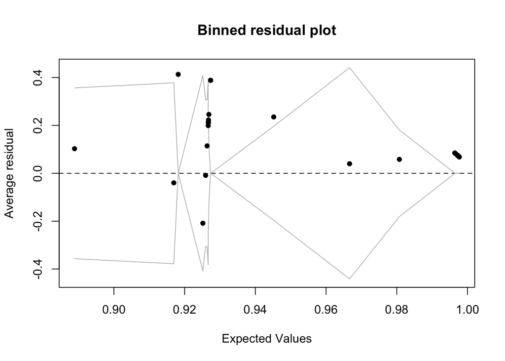

```r
binnedplot(fitted(model_subject),residuals(model_subject))
```

Let’s now build a null model to compare with our model_subject model.

```r
model_null <- glmer(Acc ~ (1 + FaceExpression | Subject), data = my_data, family = "binomial")
```

```
## boundary (singular) fit: see ?isSingular
```

```r
anova(model_subject, model_null)
```

```
## Data: my_data
## Models:
## model_null: Acc ~ (1 + FaceExpression | Subject)
## model_subject: Acc ~ FaceExpression + (1 + FaceExpression | Subject)
##               Df    AIC    BIC  logLik deviance Chisq Chi Df Pr(>Chisq)
## model_null     4 346.67 366.12 -169.34   338.67
## model_subject  5 327.94 352.25 -158.97   317.94 20.73      1  5.289e-06
##
## model_null
## model_subject ***
## ---
## Signif. codes:  0 '***' 0.001 '**' 0.01 '*' 0.05 '.' 0.1 ' ' 1
```

The two differ from each other (look at the small p-value) - with both AIC and BIC values consistently pointing towards the model_subject model as a better fit to our data.

Can you use the BIC values to estimate the Bayes factor in support of the model_subject model? What can you conclude from it?